# StepReg: Stepwise Regression Analysis

Junhui Li, Kai Hu, Xiaohuan Lu and Lihua Julie Zhu

University of Massachusset Chan Medical School, Worcester, USA  
Clark University, Worcester, USA

4 June 2026

#### Abstract

Stepwise regression is commonly used for model selection, but the absence of a unified tool supporting diverse regression types, selection strategies, and metrics has complicated its effective application. Notably, most existing tools lack built-in robust methods to address issues like invalid statistical inference and overfitting. We present StepReg, an R package designed to streamline stepwise regression analysis while promoting best practices. StepReg is a comprehensive tool that accommodates multiple regression types and incorporates commonly used selection strategies and metrics. It allows users to combine selection strategies and metrics for efficient model selection. The package offers a randomized forward selection option to avoid overfitting and a data-splitting option to adress potential issues with invalid statistical inference. Additionally, it includes functions for visualizing the selection process and exporting results in multiple formats. To ensure accuracy, StepReg was validated against public datasets using SAS, and an interactive Shiny application is included to enhance usability. This vignette provides numerous examples for model development in diverse contexts.

#### Package

StepReg 1.6.6

# 1 Introduction

Model selection is the process of identifying the most relevant features from a set of candidate variables. This step is critical for building models that are accurate, interpretable, and computationally efficient while avoiding overfitting. Stepwise regression algorithms automate this process by iteratively adding or removing features based on predefined criteria, such as statistical significance (e.g., p-values), information criteria (e.g., AIC or BIC), or other performance metrics. The procedure continues until no further improvements can be made according to the chosen criterion, resulting in a final model that includes the selected features and their corresponding coefficients.

However, it is important to note that stepwise regression should never be used for statistical inference unless the variable selection process is explicitly accounted for. Without proper adjustments, the selection process invalidates statistical inference, such as p-values and confidence intervals, due to issues like multiple testing and data dredging. This limitation does not apply when stepwise regression is used for prediction, as the primary goal in predictive modeling is to maximize accuracy rather than draw causal conclusions.

StepReg simplifies model selection tasks by providing a unified programming interface. It currently supports model buildings for five distinct response variable types (section 3.1), four model selection strategies (section 3.2) including the best subsets algorithm, and a variety of selection metrics (section 3.3). StepReg also supports advanced features including strata variables for Cox regression and continuous-nested-within-class effects for complex modeling scenarios (section 3.4). Moreover, StepReg detects and addresses the multicollinearity issues if they exist (section 3.6). The output of StepReg includes multiple tables summarizing the final model and the variable selection procedures. Additionally, StepReg offers a plot function to visualize the selection steps and support a various formats of output (section 4). For demonstration, the vignettes include four use cases covering distinct regression scenarios (section 5). Non-programmers can access the tool through an interactive Shiny application (section 6).

By combining flexibility, robustness, and ease of use, StepReg is a powerful tool for predictive modeling tasks, particularly when the goal is to identify an optimal set of features for accurate predictions. However, users should exercise caution and avoid using StepReg for statistical inference unless the variable selection process is properly accounted for.

# 2 Quick demo

The following example selects an optimal linear regression model with the `mtcars` dataset.

```r
library(StepReg)
data(mtcars)
formula <- mpg ~ .
res <- stepwise(formula = formula,
                data = mtcars,
                type = "linear",
                include = c("qsec"),
                strategy = "bidirection",
                metric = c("AIC"))
```

Breakdown of the parameters:

- `formula`: specifies the dependent and independent variables
- `type`: specifies the regression category, depending on your data, choose from “linear”, “logit”, “cox”, etc.
- `include`: specifies the variables that must be in the final model
- `strategy`: specifies the stepwise strategy, choose from “forward”, “backward”, “bidirection”, “subset”
- `metric`: specifies the model fit evaluation metric, choose one or more from “AIC”, “AICc”, “BIC”, “SL”, etc.

The output consists of final model, which can be viewed using:

```r
res
```

```
$bidirection
$bidirection$AIC

Call:
lm(formula = mpg ~ 1 + qsec + wt + am, data = data, weights = NULL)

Coefficients:
(Intercept)         qsec           wt           am
      9.618        1.226       -3.917        2.936
```

You can further explore the results with S3 generic functions such as `summary()`, `coeff()`, and others. For example:

```r
summary(res$bidirection$AIC)
```

```
Call:
lm(formula = mpg ~ 1 + qsec + wt + am, data = data, weights = NULL)

Residuals:
    Min      1Q  Median      3Q     Max
-3.4811 -1.5555 -0.7257  1.4110  4.6610

Coefficients:
            Estimate Std. Error t value Pr(>|t|)
(Intercept)   9.6178     6.9596   1.382 0.177915
qsec          1.2259     0.2887   4.247 0.000216 ***
wt           -3.9165     0.7112  -5.507 6.95e-06 ***
am            2.9358     1.4109   2.081 0.046716 *
---
Signif. codes:  0 '***' 0.001 '**' 0.01 '*' 0.05 '.' 0.1 ' ' 1

Residual standard error: 2.459 on 28 degrees of freedom
Multiple R-squared:  0.8497,    Adjusted R-squared:  0.8336
F-statistic: 52.75 on 3 and 28 DF,  p-value: 1.21e-11
```

You can also visualize the variable selection procedures with:

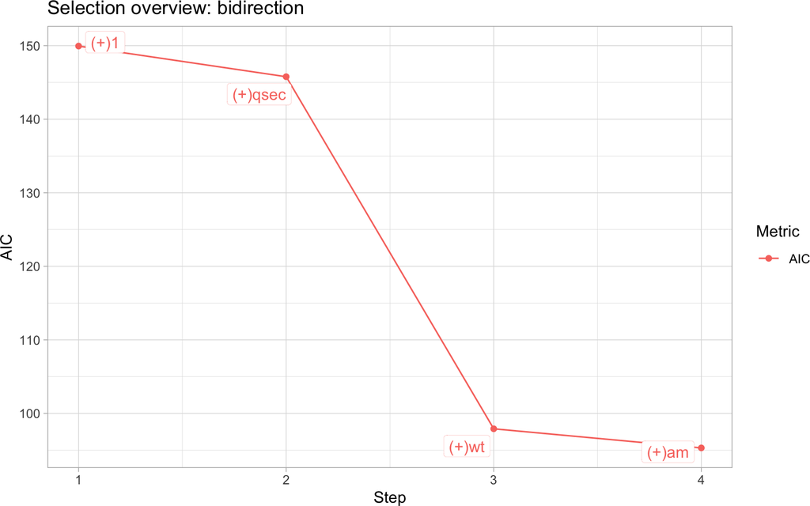

```r
plot(res, strategy = "bidirection", process = "overview")
```

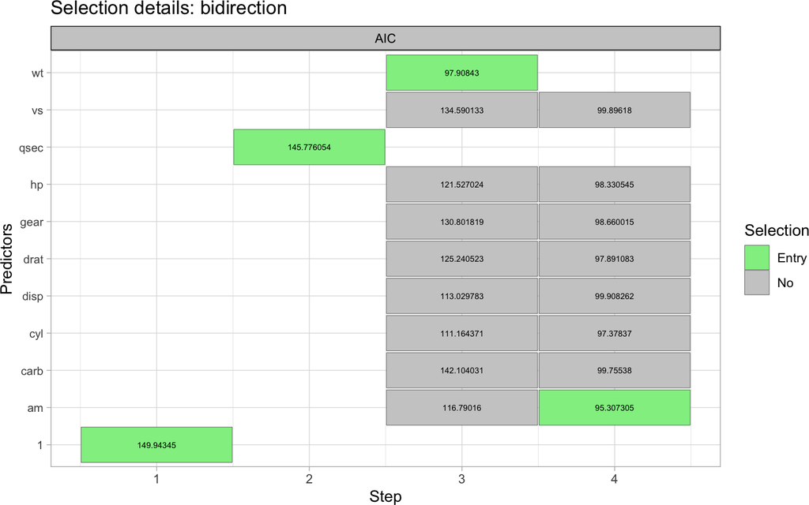

```r
plot(res, strategy = "bidirection", process = "detail")
```

The `(+)1` refers to original model with intercept being added, `(+)` indicates variables being added to the model while `(-)` means variables being removed from the model.

Additionally, you can generate reports of various formats with:

```r
report(res, report_name = "path_to/demo_res", format = "html")
```

Replace `"path_to/demo_res"` with desired output file name, the suffix `".html"` will be added automatically. For detailed examples and more usage, refer to section 4 and 5.

# 3 Key features

## 3.1 Regression categories

**StepReg** supports multiple types of regressions, including *linear*, *logit*, *cox*, *poisson*, and *gamma* regressions. These methods primarily vary by the type of response variable, which are summarized in the table below. Additional regression techniques can be incorporated upon user requests.

Table 1: Common regression categories

| Regression | Reponse |
| --- | --- |
| linear | continuous |
| logit | binary |
| cox | time-to-event |
| poisson | count |
| gamma | continuous and positively skewed |

## 3.2 Model selection strategies

Model selection aims to identify the subset of independent variables that provide the best predictive performance for the response variable. Both stepwise regression and best subsets approaches are implemented in StepReg. For stepwise regression, there are mainly three methods: *Forward Selection*, *Backward Elimination*, *Bidirectional Elimination*.

Table 2: Model selection strategy

| Strategy | Description |
| --- | --- |
| Forward Selection | In forward selection, the algorithm starts with an empty model (no predictors) and adds in variables one by one. Each step tests the addition of every possible predictor by calculating a pre-selected … |
| Backward Elimination | In backward elimination, the algorithm starts with a full model (all predictors) and deletes variables one by one. Each step test the deletion of every possible predictor by calculating a pre-selected… |
| Bidirectional Elimination | Bidirectional elimination is essentially a forward selection procedure combined with backward elimination at each iteration. Each iteration starts with a forward selection step that adds in predictors… |
| Best Subsets | Stepwise algorithms add or delete one predictor at a time and output a single model without evaluating all candidates. Therefore, it is a relatively simple procedure that only produces one model. In c… |

Given the computational constraints, when dealing with datasets featuring a substantial number of predictor variables greater than the sample size, the Bidirectional Elimination typically emerges as the most advisable approach. Forward Selection and Backward Elimination can be considered in sequence. On the contrary, the Best Subsets approach requires the most substantial processing time, yet it calculates a comprehensive set of models with varying numbers of variables. In practice, users can experiment with various methods and select a final model based on the specific dataset and research objectives at hand.

## 3.3 Selection metrics

Various *selection metrics* can be used to guide the process of adding or removing predictors from the model. These metrics help to determine the importance or significance of predictors in improving the model fit. In StepReg, selection metrics include two categories: *Information Criteria* and *Significance Level* of the coefficient associated with each predictor. *Information Criteria* is a means of evaluating a model’s performance, which balances model fit with complexity by penalizing models with a higher number of parameters. Lower *Information Criteria* values indicate a better trade-off between model fit and complexity. Note that when evaluating different models, it is important to compare them within the same *Information Criteria* framework rather than across multiple Information Criteria. For example, if you decide to use AIC, you should compare all models using AIC. This ensures consistency and fairness in model comparison, as each Information Criterion has its own scale and penalization factors. In practice, multiple metrics have been proposed, the ones supported by StepReg are summarized below.

Importantly, given the discrepancies in terms of the precise definitions of each metric, StepReg mirrors the formulas adopted by [SAS](https://documentation.sas.com/doc/en/statcdc/14.2/statug/statug_glmselect_details15.htm) for *univariate multiple regression (UMR)* except for HQ, IC(1), and IC(3/2). A subset of the UMR can be easily extended to *multivariate multiple regression (MMR)*, which are indicated in the following table.

Table 3: Statistics in selection metric

| Statistic | Meanings |
| --- | --- |
| ${n}$ | Sample Size |
| ${p}$ | Number of parameters including the intercept |
| ${q}$ | Number of dependent variables |
| $\sigma^2$ | Estimate of pure error variance from fitting the full model |
| ${SST}$ | Total sum of squares corrected for the mean for the dependent variable, which is a numeric value for UMR and a matrix for multivariate regression |
| ${SSE}$ | Error sum of squares, which is a numeric value for UMR and a matrix for multivariate regression |
| $\text{LL}$ | The natural logarithm of likelihood |
| ${\| \|}$ | The determinant function |
| $\ln()$ | The natural logarithm |

Table 4: Abbreviation, Definition, and Formula of the Selection Metric for Linear, Logit, Cox, Possion, and Gamma regression

| Abbreviation | Definition | Formula |  |
| --- | --- | --- | --- |
|  |  | linear | logit, cox, poisson and gamma |
| AIC | Akaike’s Information Criterion | $n\ln\left(\frac{\|\text{SSE}\|}{n}\right) + 2pq + n + q(q+1)$ (Clifford M. Hurvich 1989; Al-Subaihi 2002)$^1$ | $-2\text{LL} + 2p$ (Darlington 1968; George G. Judge 1985) |
| AICc | Corrected Akaike’s Information Criterion | $n\ln\left(\frac{\|\text{SSE}\|}{n}\right) + \frac{nq(n+p)}{n-p-q-1}$ (Clifford M. Hurvich 1989; Edward J. Bedrick 1994)$^2$ | $-2\text{LL} + \frac{n(n+p)}{n-p-2}$ (Clifford M. Hurvich 1989) |
| BIC | Sawa Bayesian Information Criterion | $n\ln\left(\frac{SSE}{n}\right) + 2(p+2)o - 2o^2, o = \frac{n\sigma^2}{SSE}$ (Sawa 1978; George G. Judge 1985) not available for MMR | not available |
| Cp | Mallows’ Cp statistic | $\frac{SSE}{\sigma^2} + 2p - n$ (Mallows 1973; Hocking 1976) not available for MMR | not available |
| HQ | Hannan and Quinn Information Criterion | $n\ln\left(\frac{\|\text{SSE}\|}{n}\right) + 2pq\ln(\ln(n))$ (E. J. Hannan 1979; Allan D R McQuarrie 1998; Clifford M. Hurvich 1989) | $-2\text{LL} + 2p\ln(\ln(n))$ (E. J. Hannan 1979) |
| IC(1) | Information Criterion with Penalty Coefficient Set to 1 | $n\ln\left(\frac{\|\text{SSE}\|}{n}\right) + p$ (J. A. Nelder 1972; A. F. M. Smith 1980) not available for MMR | $-2\text{LL} + p$ (J. A. Nelder 1972; A. F. M. Smith 1980) |
| IC(3/2) | Information Criterion with Penalty Coefficient Set to 3/2 | $n\ln\left(\frac{\|\text{SSE}\|}{n}\right) + \frac{3}{2}p$ (A. F. M. Smith 1980) not available for MMR | $-2\text{LL} + \frac{3}{2}p$ (A. F. M. Smith 1980) |
| SBC | Schwarz Bayesian Information Criterion | $n\ln\left(\frac{\|\text{SSE}\|}{n}\right) + pq \ln(n)$ (Clifford M. Hurvich 1989; Schwarz 1978; George G. Judge 1985; Al-Subaihi 2002) not available for MMR | $-2\text{LL} + p\ln(n)$ (Schwarz 1978; George G. Judge 1985) |
| SL | Significance Level (pvalue) | $\textit{F test}$ for UMR and $\textit{Approximate F test}$ for MMR | Forward: LRT and Rao Chi-square test (logit, poisson, gamma); LRT (cox); Backward: Wald test |
| adjRsq | Adjusted R-square statistic | $1 - \frac{(n-1)(1-R^2)}{n-p}$, where $R^2=1 - \frac{SSE}{SST}$ (Darlington 1968; George G. Judge 1985) not available for MMR | not available |

<sup>1</sup> Unsupported AIC formula (which does not affect the selection process as it only differs by constant additive and multiplicative factors): $AIC=n\ln\left(\frac{SSE}{n}\right) + 2p$ (Darlington 1968; George G. Judge 1985)  
<sup>2</sup> Unsupported AICc formula (which does not affect the selection process as it only differs by constant additive and multiplicative factors): $AICc=\ln\left(\frac{SSE}{n}\right) + 1 + \frac{2(p+1)}{n-p-2}$ (Allan D R McQuarrie 1998)

No metric is necessarily optimal for all datasets. The choice of them depends on your data and research goals. We recommend using multiple metrics simultaneously, which allows the selection of the best model based on your specific needs. Below summarizes general guidance.

- AIC: AIC works by penalizing the inclusion of additional variables in a model. The lower the AIC, the better performance of the model. AIC does not include sample size in penalty calculation, and it is optimal in minimizing the mean square error of predictions (Mark J. Brewer 2016).
- AICc: AICc is a variant of AIC, which works better for small sample size, especially when `numObs / numParam < 40` (Kenneth P. Burnham 2002).
- Cp: Cp is used for linear models. It is equivalent to AIC when dealing with Gaussian linear model selection.
- IC(1) and IC(3/2): IC(1) and IC(3/2) have 1 and 3/2 as penalty factors respectively, compared to 2 used by AIC. As such, IC(1) turns to return a complex model with more variables that may suffer from overfitting issues.
- BIC and SBC: Both BIC and SBC are variants of Bayesian Information Criterion. The main distinction between BIC/SBC and AIC lies in the magnitude of the penalty imposed: BIC/SBC are more parsimonious when penalizing model complexity, which typically results to a simpler model (SAS Institute Inc 2018; Sawa 1978; Clifford M. Hurvich 1989; Schwarz 1978; George G. Judge 1985; Al-Subaihi 2002).

The precise definitions of these criteria can vary across literature and in the SAS environment. Here, BIC aligns with the definition of the Sawa Bayesion Information Criterion as outlined in [SAS](https://documentation.sas.com/doc/en/pgmsascdc/9.4_3.3/statug/statug_glmselect_syntax07.htm) documentation, while SBC corresponds to the Schwarz Bayesian Information Criterion. According to Richard’s [post](https://www.linkedin.com/pulse/aicbic-model-selection-richard-randa/), whereas AIC often favors selecting overly complex models, BIC/SBC prioritize a small models. Consequently, when dealing with a limited sample size, AIC may seem preferable, whereas BIC/SBC tend to perform better with larger sample sizes.

- HQ: HQ is an alternative to AIC, differing primarily in the method of penalty calculation. However, HQ has remained relatively underutilized in practice (Kenneth P. Burnham 2002).
- adjRsq: The adjusted R-squared (adj-R²) seeks to overcome the limitation of R-squared in model selection by considering the number of predictors. It serves a similar purpose to information criteria, as both methods compare models by weighing their goodness of fit against the number of parameters. However, information criteria are typically regarded as superior in this context (Stevens 2016).
- SL: SL stands for Significance Level (P-value), embodying a distinct approach to model selection in contrast to information criteria. The SL method operates by calculating a P-value through specific hypothesis testing. Should this P-value fall below a predefined threshold, such as 0.05, one should favor the alternative hypothesis, indicating that the full model significantly outperforms the reduced model. The effectiveness of this method hinges upon the selection of the P-value threshold, wherein smaller thresholds tend to yield simpler models.

## 3.4 Advanced Features

StepReg supports several advanced features that enhance its flexibility for complex modeling scenarios.

### 3.4.1 Strata Variables in Cox Regression

For Cox proportional hazards regression, StepReg supports the use of `strata()` function to include stratification variables. This is particularly useful when you want to control for confounding variables that may violate the proportional hazards assumption.

The `strata()` function allows you to fit separate baseline hazard functions for different groups while sharing the same regression coefficients across strata. This is equivalent to fitting separate Cox models for each stratum but with the advantage of more efficient parameter estimation.

Here is an example of how to use the `strata()` function in a formula for StepReg:

```r
formula  =  Surv(time, status) ~ . + strata(inst)
```

In this example, `strata(inst)` creates separate baseline hazard functions for each institution (`inst`), while the effects of other selected variables are assumed to be the same across all institutions.

### 3.4.2 Continuous-Nested-Within-Class Effects

StepReg supports continuous-nested-within-class effects, which are useful when you want to model how a continuous variable’s effect varies across different levels of a categorical variable. This is implemented using the `:` operator in the formula.

**Key points about continuous-nested-within-class effects:**

- The class variable (categorical) must be a factor
- The continuous variable can be nested within the class variable using `:` notation
- The order of variables in the nested term doesn’t matter (e.g., `X:A` is equivalent to `A:X`)

here is an example of how to use the `:` operator in a formula for StepReg:

```r
mtcars$am <- as.factor(mtcars$am)
formula <- mpg ~ am + cyl:am + wt:am + disp:am + hp:am + qsec:am + vs:am + gear:am + carb:am
```

### 3.4.3 Multivariate multiple regression for linear regression

StepReg supports multivariate multiple regression, which is a type of regression analysis that allows for multiple response variables to be modeled simultaneously. This is implemented using the `cbind()` operator in the formula.

here is an example of how to use the `cbind()` operator in a formula for StepReg:

```r
formula <- cbind(mpg, drat) ~ .
```

## 3.5 Formula Syntax Summary

The following table summarizes the formula syntax supported by StepReg:

Table 5: Formula syntax supported by StepReg

| Syntax | Description | Example |
| --- | --- | --- |
| `y ~ x1 + x2` | Multiple predictors | `mpg ~ cyl + wt` |
| `y ~ .` | All variables in dataset | `mpg ~ .` |
| `y ~ . - x1` | All variables except x1 | `mpg ~ . - disp` |
| `y ~ x1 * x2` | Main effects and interaction | `mpg ~ cyl * am` |
| `y ~ x1:x2` | Continuous-nested-within-class effects | `mpg ~ cyl:am` |
| `cbind(y1, y2) ~ .` | Multiple response variables | `cbind(mpg, drat) ~ .` |
| `y ~ . + 0` or `y ~ . - 1` | No intercept | `mpg ~ . + 0` |
| `Surv(time, status) ~ . + strata(strata_var)` | Cox regression with strata | `Surv(time, status) ~ age + sex + strata(inst)` |

## 3.6 Multicollinearity

Multicollinearity arises when independent variables in a regression model are correlated with each other. Ideally, predictors should be independent to allow a clear understanding of how each variable relates to the outcome. When the correlations between predictors are strong, it can create significant issues for model fitting and interpretation. In such cases, changes in one input variable can be associated with changes in others, which makes it difficult to assess each variable’s individual contribution to the dependent variable.

Severe multicollinearity reduces the precision of estimated regression coefficients, thereby complicating model selection and interpretation. It can lead to unreliable estimates and inflated standard errors. However, it is important to note that multicollinearity primarily affects the interpretation of coefficients and their statistical significance. If the main objective is to predict outcomes accurately, and interpretation of individual predictors is not required, addressing multicollinearity may not be necessary because it does not impact prediction accuracy or the goodness-of-fit of the model.

In StepReg, QC Matrix Decomposition is performed ahead of time to detect and remove input variables causing multicollinearity.

# 4 StepReg output

This function creates a StepReg class object, which is a structured list containing both the input specifications and the outcomes of the stepwise regression analysis. The key components of this object are detailed below, providing a comprehensive framework for model exploration and validation.

- **`argument`**: A data.frame containing the user-specified settings and parameters used in the analysis, including the initial formula, regression type, selection strategy, chosen metrics, significance levels (sle/sls), tolerance threshold, test method, and other control parameters.
- **`variable`**: A data.frame containing information about all variables in the model, including variable names, data types (numeric, factor, etc.), and their roles (Dependent/Independent) in the model.
- **`performance`**: A data.frame containing model-level performance metrics for each strategy-by-criterion. The model evaluation metrics vary by regression type:
  - For linear, Poisson, Gamma, and negative binomial regression models, the key performance indicators for both training and test data sets include adjusted R-squared (adjR-squared_train / adjR-squared_test applicable only to linear regression), mean squared error (mse_train / mse_test) and mean absolute error (mae_train / mae_test). A higher adjusted R-squared and lower MSE or MAE generally indicate a better model fit, while a large discrepancy between training and test metrics often signals overfitting, suggesting the model may not generalize well to unseen data. Note: If the adjusted R-squared for the test set exceeds 1, this is typically due to the small size of the test sample, which can produce unstable or non-interpretable values for this statistic.
  - For logistic regression models, the key performance indicators for both training and test data sets include accuracy (accuracy_train / accuracy_test), area under the receiver operating characteristic (ROC) curve (AUC) (auc_train / auc_test), and log loss (log_loss_train / log_loss_test). Higher accuracy and AUC values, combined with lower log loss, generally indicate stronger predictive performance. As with other models, substantial gaps between training and testing results suggest potential overfitting and warrant further investigation.
  - For Cox proportional hazards regression models, the primary performance indicators are concordance index (c_index_train / c_index_test) and time-dependent area under the curve (auc_sh). Higher values indicate stronger discrimination between risk groups. The c-index ranges from 0.5 (random prediction) to 1.0 (perfect prediction). Values below 0.5 typically suggest reversed risk direction or miscoding of events. In such cases, verify event coding and ensure that the scoring system aligns with the interpretation that higher scores correspond to higher risk.
- **`overview`**: A nested list organized by strategy and metric, containing step-by-step summaries of the model-building process. Each element shows which variables were entered or removed at each step along with the corresponding metric values (e.g., AIC, BIC, SBC).
- **`detail`**: A nested list organized by strategy and metric, providing granular information about each candidate step. This includes which variables were tested, their evaluation statistics, p-values, and whether they were ultimately selected or rejected.
- **`fitted models (within the strategy-metric hierarchy)`**: For each combination of selection strategy (e.g., “forward”, “backward”, “bidirection”, “subset”) and metric (e.g., “AIC”, “BIC”, “SBC”), the object stores the corresponding fitted model. These can be analyzed with standard S3 generics, `summary()`, `anova()`, `plot()`, or `coef()`, which dispatch to the underlying model class (e.g., `coxph()`, `lm()`, `glm()`). Users can also access components directly, e.g., result$forward$AIC$coefficients. Note: “coxph” objects in the `survival` package include detailed summaries (hazard ratios, standard errors, test statistics), whereas `lm()` / `glm()` display only basic coefficients by default. Use `summary()` to obtain standard errors, t/z statistics, p values, and R-squared.

# 5 Use cases

Below, we present various examples illustrating the application of different models tailored to specific datasets. Please note that stepwise regression should never be used for statistical inference unless the variable selection process is properly accounted for, as it can invalidate the results. However, this issue does not arise when stepwise regression is used for prediction. It is essential to select the regression model that best suits the type of response variable. For detailed guidance, refer to section 3.1.

## 5.1 Linear regression with the *mtcars* dataset

In this section, we’ll demonstrate how to perform linear regression analysis using the [mtcars](https://stat.ethz.ch/R-manual/R-devel/library/datasets/html/mtcars.html) dataset, showcasing different scenarios with varying numbers of predictors and dependent variables. We set `type = "linear"` to direct the function to perform linear regression.

**Description of the `mtcars` dataset**

The `mtcars` is a classic dataset in statistics and is included in the base R installation. It was sourced from the 1974 *Motor Trend* US magazine, comprising 32 observations on 11 variables. Here’s a brief description of the variables included:

1. mpg: miles per gallon (fuel efficiency)
2. cyl: number of cylinders
3. disp: displacement (engine size) in cubic inches
4. hp: gross horsepower
5. drat: rear axle ratio
6. wt: weight (in thousands of pounds)
7. qsec: 1/4 mile time (in seconds)
8. vs: engine type (0 = V-shaped, 1 = straight)
9. am: transmission type (0 = automatic, 1 = manual)
10. gear: number of forward gears
11. carb: number of carburetors

**Why choose linear regression**

Linear regression is an ideal choice for analyzing the `mtcars` dataset due to its inclusion of continuous variables like “mpg”, “hp”, or “weight”, which can serve as response variables. Furthermore, the dataset exhibits potential linear relationships between the response variable and other variables.

### 5.1.1 Example1: single dependent variable (“mpg”), and apply continuous-nested-within-class variables

```r
data(mtcars)
## make sure the categorical variable is a factor variable
mtcars$am <- as.factor(mtcars$am)
str(mtcars)
```

```
'data.frame':   32 obs. of  11 variables:
 $ mpg : num  21 21 22.8 21.4 18.7 18.1 14.3 24.4 22.8 19.2 ...
 $ cyl : num  6 6 4 6 8 6 8 4 4 6 ...
 $ disp: num  160 160 108 258 360 ...
 $ hp  : num  110 110 93 110 175 105 245 62 95 123 ...
 $ drat: num  3.9 3.9 3.85 3.08 3.15 2.76 3.21 3.69 3.92 3.92 ...
 $ wt  : num  2.62 2.88 2.32 3.21 3.44 ...
 $ qsec: num  16.5 17 18.6 19.4 17 ...
 $ vs  : num  0 0 1 1 0 1 0 1 1 1 ...
 $ am  : Factor w/ 2 levels "0","1": 2 2 2 1 1 1 1 1 1 1 ...
 $ gear: num  4 4 4 3 3 3 3 4 4 4 ...
 $ carb: num  4 4 1 1 2 1 4 2 2 4 ...
```

```r
formula <- mpg ~ am + cyl:am + disp:am + am:hp + drat:am + wt:am + qsec:am + vs:am + gear:am + carb:am
res1 <- stepwise(formula = formula,
                 data = mtcars,
                 type = "linear",
                 include = c("cyl:am", "am"),
                 strategy = "forward",
                 metric = "AIC",
                 test_ratio = 0.2)
res1
```

```
$forward
$forward$AIC

Call:
lm(formula = mpg ~ 1 + cyl:am + am + am:wt + am:qsec + am:carb +
    am:gear + am:vs, data = data, weights = NULL)

Coefficients:
(Intercept)          am1      cyl:am0      cyl:am1       am0:wt       am1:wt
    18.5828     -98.4083      -1.3517       2.4525       3.2872      -9.2107
   am0:qsec     am1:qsec     am0:carb     am1:carb     am0:gear     am1:gear
    -0.2891       5.0370      -2.0607       0.4417       2.2797       6.1378
     am0:vs       am1:vs
     1.2148      -3.3619
```

To get the summary of the model:

```r
summary(res1$forward$AIC)
```

```
Call:
lm(formula = mpg ~ 1 + cyl:am + am + am:wt + am:qsec + am:carb +
    am:gear + am:vs, data = data, weights = NULL)

Residuals:
     Min       1Q   Median       3Q      Max
-1.69185 -0.93906 -0.04013  0.73942  2.97790

Coefficients:
            Estimate Std. Error t value Pr(>|t|)
(Intercept)  18.5828    13.9674   1.330  0.20810
am1         -98.4083    34.8924  -2.820  0.01545 *
cyl:am0      -1.3517     1.0704  -1.263  0.23065
cyl:am1       2.4525     1.2507   1.961  0.07352 .
am0:wt        3.2872     2.6429   1.244  0.23733
am1:wt       -9.2107     2.4546  -3.752  0.00276 **
am0:qsec     -0.2891     0.6024  -0.480  0.63988
am1:qsec      5.0370     1.2513   4.025  0.00168 **
am0:carb     -2.0607     0.7748  -2.660  0.02080 *
am1:carb      0.4417     0.5052   0.874  0.39911
am0:gear      2.2797     2.2775   1.001  0.33661
am1:gear      6.1378     2.2268   2.756  0.01740 *
am0:vs        1.2148     2.4968   0.487  0.63536
am1:vs       -3.3619     2.3399  -1.437  0.17634
---
Signif. codes:  0 '***' 0.001 '**' 0.01 '*' 0.05 '.' 0.1 ' ' 1

Residual standard error: 1.674 on 12 degrees of freedom
Multiple R-squared:  0.9617,    Adjusted R-squared:  0.9203
F-statistic: 23.21 on 13 and 12 DF,  p-value: 1.722e-06
```

The performance of the model:

```r
performance(res1)
```

```
                                                                    model
1 mpg:mpg ~ 1 + cyl:am + am + am:wt + am:qsec + am:carb + am:gear + am:vs
  strategy:metric adjR-squared_train adjR-squared_test mse_train mse_test
1     forward:AIC             0.9203            1.1336    1.2939  11.0821
  mae_train mae_test response
1    0.8941   1.7781      mpg
```

To visualize the selection process:

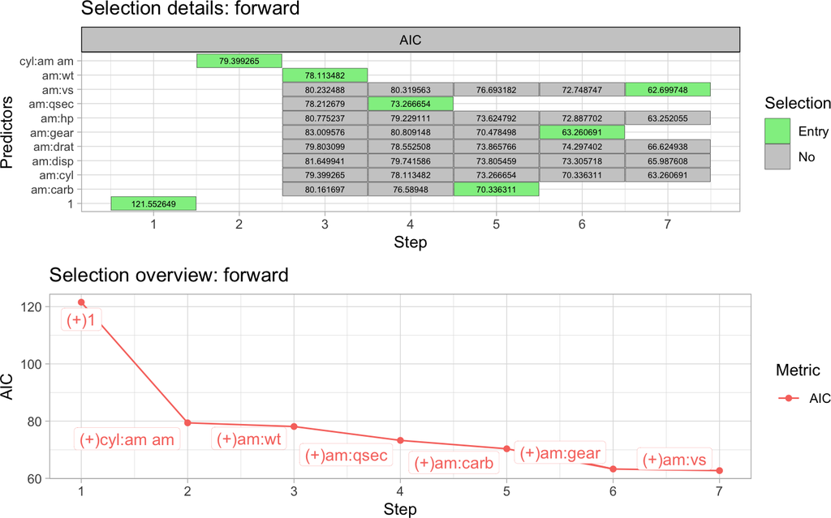

```r
plot_list <- list()
plot_list[["forward"]][["detail"]] <- plot(res1, process = "detail")
plot_list[["forward"]][["overview"]] <- plot(res1, process = "overview")
cowplot::plot_grid(plotlist = plot_list$forward, ncol = 1)
```

To exclude the intercept from the model, adjust the formula as follows:

```r
formula <- mpg ~ . + 0
```

```r
formula <- mpg ~ . - 1
```

To limit the model to a specific subset of predictors, adjust the formula as follows, which will only consider “cyp”, “disp”, “hp”, “wt”, “vs”, and “am” as the predictors.

```r
formula <- mpg ~ cyl + disp + hp + wt + vs + am + 0
```

Another way is to use minus symbol(`"-"`) to exclude some predictors for variable selection. For example, include all variables except “disp”, “wt”, and intercept.

```r
formula <- mpg ~ . - 1 - disp - wt
```

You can simultaneously provide multiple selection strategies and metrics. For example, the following code snippet employs both “forward” and “backward” strategies using metrics “AIC”, “BIC”, and “SL”. It’s worth mentioning that when “SL” is specified, you may also want to set the significance level for entry (“sle”) and stay (“sls”), both of which default to 0.15.

```r
formula <- mpg ~ .
res2 <- stepwise(formula = formula,
                 data = mtcars,
                 type = "linear",
                 strategy = c("forward", "backward"),
                 metric = c("AIC", "BIC", "SL"),
                 sle = 0.05,
                 sls = 0.05,
                 test_ratio = 0.3)
res2
```

```
$forward
$forward$AIC

Call:
lm(formula = mpg ~ 1 + wt + qsec, data = data, weights = NULL)

Coefficients:
(Intercept)           wt         qsec
    25.8451      -5.9952       0.7336


$forward$BIC

Call:
lm(formula = mpg ~ 1 + wt + qsec, data = data, weights = NULL)

Coefficients:
(Intercept)           wt         qsec
    25.8451      -5.9952       0.7336


$forward$SL

Call:
lm(formula = mpg ~ 1 + wt + qsec, data = data, weights = NULL)

Coefficients:
(Intercept)           wt         qsec
    25.8451      -5.9952       0.7336



$backward
$backward$AIC

Call:
lm(formula = mpg ~ 1 + disp + hp + wt + qsec + gear, data = data,
    weights = NULL)

Coefficients:
(Intercept)         disp           hp           wt         qsec         gear
   13.54553      0.02732     -0.02777     -6.19757      0.87649      2.29452


$backward$BIC

Call:
lm(formula = mpg ~ 1 + drat + gear + carb, data = data, weights = NULL)

Coefficients:
(Intercept)         drat         gear         carb
      1.143        3.097        3.915       -2.272


$backward$SL

Call:
lm(formula = mpg ~ 1 + wt + qsec, data = data, weights = NULL)

Coefficients:
(Intercept)           wt         qsec
    25.8451      -5.9952       0.7336
```

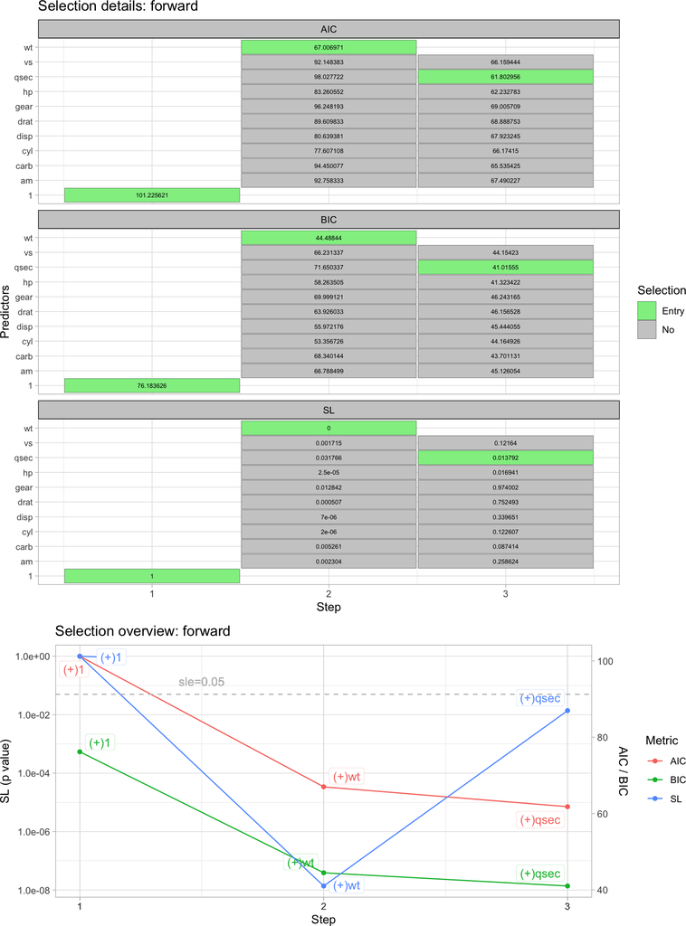

```r
plot_list <- setNames(
  lapply(c("forward", "backward"),function(i){
    setNames(
      lapply(c("detail","overview"),function(j){
        plot(res2,strategy=i,process=j)
    }),
    c("detail","overview")
    )
  }),
  c("forward", "backward")
)

cowplot::plot_grid(plotlist = plot_list$forward, ncol = 1, rel_heights = c(2, 1))
```

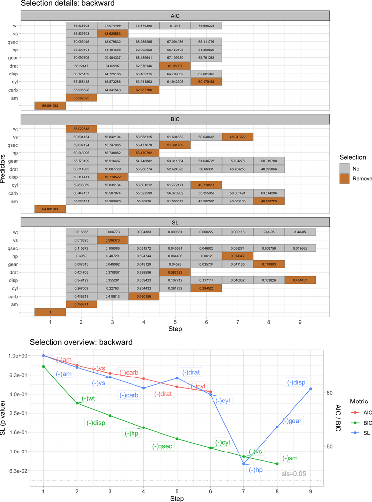

```r
cowplot::plot_grid(plotlist = plot_list$backward, ncol = 1, rel_heights = c(2, 1))
```

To get the summary of the model:

```r
summary(res2$forward$SL)
```

```
Call:
lm(formula = mpg ~ 1 + wt + qsec, data = data, weights = NULL)

Residuals:
    Min      1Q  Median      3Q     Max
-4.2465 -1.2684 -0.4813  0.9276  4.4572

Coefficients:
            Estimate Std. Error t value Pr(>|t|)
(Intercept)  25.8451     5.6843   4.547 0.000221 ***
wt           -5.9952     0.6356  -9.433 1.34e-08 ***
qsec          0.7336     0.2704   2.713 0.013792 *
---
Signif. codes:  0 '***' 0.001 '**' 0.01 '*' 0.05 '.' 0.1 ' ' 1

Residual standard error: 2.217 on 19 degrees of freedom
Multiple R-squared:  0.8611,    Adjusted R-squared:  0.8464
F-statistic: 58.88 on 2 and 19 DF,  p-value: 7.189e-09
```

The performance of the model:

```r
performance(res2)
```

```
                                       model
1                    mpg:mpg ~ 1 + wt + qsec
2 mpg:mpg ~ 1 + disp + hp + wt + qsec + gear
3           mpg:mpg ~ 1 + drat + gear + carb
                                    strategy:metric adjR-squared_train
1 forward:AIC; forward:BIC; forward:SL; backward:SL             0.8464
2                                      backward:AIC             0.8711
3                                      backward:BIC             0.7943
  adjR-squared_test mse_train mse_test mae_train mae_test response
1            0.8473    4.2444   5.3084    1.6617   1.7531      mpg
2            0.7794    3.0014   4.9243    1.2997   1.4593      mpg
3            0.8082    5.3868   6.4444    1.8027   2.0809      mpg
```

Saving the results:

```r
report(res2, report_name = "results", format = c("html", "docx"))
```

### 5.1.2 Example2: multivariate regression (“mpg” and “drat”)

In this scenario, there are two dependent variables, “mpg” and “drat”. The model selection aims to identify the most influential predictors that affect both variables.

```r
formula <- cbind(mpg, drat) ~ . + 0
res3 <- stepwise(formula = formula,
                 data = mtcars,
                 type = "linear",
                 strategy = "bidirection",
                 metric = c("AIC", "HQ"),
                 test_ratio=0.2,
                 feature_ratio = 0.9)
res3
```

```
$bidirection
$bidirection$AIC

Call:
lm(formula = cbind(mpg, drat) ~ 0 + am + cyl + carb, data = data,
    weights = NULL)

Coefficients:
      mpg       drat
am0   32.82321   4.41965
am1   37.04570   4.78713
cyl   -1.72726  -0.17784
carb  -1.12739   0.06065


$bidirection$HQ

Call:
lm(formula = cbind(mpg, drat) ~ 0 + gear + qsec + wt + cyl, data = data,
    weights = NULL)

Coefficients:
      mpg      drat
gear   1.4101   0.4547
qsec   1.7009   0.1332
wt    -7.1519  -0.3680
cyl    1.1321   0.1113
```

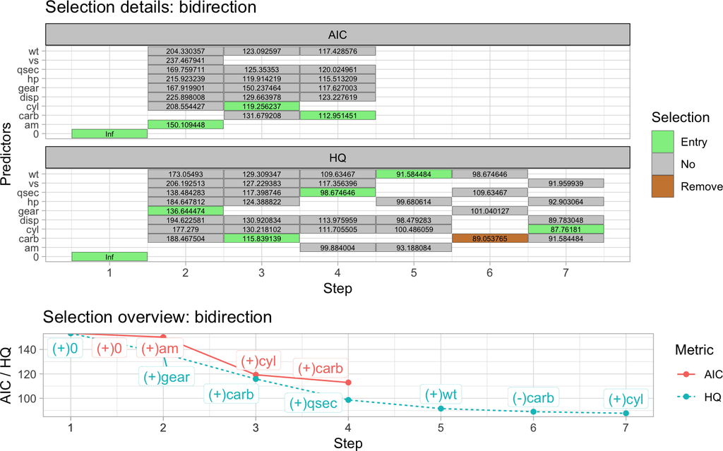

```r
plot_list <- setNames(
  lapply(c("bidirection"),function(i){
    setNames(
      lapply(c("detail","overview"),function(j){
        plot(res3,strategy=i,process=j)
    }),
    c("detail","overview")
    )
  }),
  c("bidirection")
)

cowplot::plot_grid(plotlist = plot_list$bidirection, ncol = 1, rel_heights = c(2, 1))
```

To get the summary of the model:

```r
summary(res3$bidirection$AIC)
```

```
Response mpg :

Call:
lm(formula = mpg ~ 0 + am + cyl + carb, data = data, weights = NULL)

Residuals:
    Min      1Q  Median      3Q     Max
-6.2093 -1.2367 -0.1729  1.5702  4.8907

Coefficients:
     Estimate Std. Error t value Pr(>|t|)
am0   32.8232     2.2882  14.344 1.20e-12 ***
am1   37.0457     1.7428  21.256 3.72e-16 ***
cyl   -1.7273     0.3913  -4.414  0.00022 ***
carb  -1.1274     0.3766  -2.993  0.00670 **
---
Signif. codes:  0 '***' 0.001 '**' 0.01 '*' 0.05 '.' 0.1 ' ' 1

Residual standard error: 2.488 on 22 degrees of freedom
Multiple R-squared:  0.989, Adjusted R-squared:  0.987
F-statistic: 494.6 on 4 and 22 DF,  p-value: < 2.2e-16


Response drat :

Call:
lm(formula = drat ~ 0 + am + cyl + carb, data = data, weights = NULL)

Residuals:
     Min       1Q   Median       3Q      Max
-0.46396 -0.13189 -0.05641  0.08872  0.73294

Coefficients:
     Estimate Std. Error t value Pr(>|t|)
am0   4.41965    0.29887  14.788 6.54e-13 ***
am1   4.78713    0.22763  21.030 4.65e-16 ***
cyl  -0.17784    0.05111  -3.479  0.00213 **
carb  0.06065    0.04919   1.233  0.23065
---
Signif. codes:  0 '***' 0.001 '**' 0.01 '*' 0.05 '.' 0.1 ' ' 1

Residual standard error: 0.325 on 22 degrees of freedom
Multiple R-squared:  0.9935,    Adjusted R-squared:  0.9923
F-statistic:   835 on 4 and 22 DF,  p-value: < 2.2e-16
```

The performance of the model:

```r
performance(res3)
```

```
                                          model strategy:metric
1        cbind(mpg, drat) ~ 0 + am + cyl + carb bidirection:AIC
2        cbind(mpg, drat) ~ 0 + am + cyl + carb bidirection:AIC
3 cbind(mpg, drat) ~ 0 + gear + qsec + wt + cyl  bidirection:HQ
4 cbind(mpg, drat) ~ 0 + gear + qsec + wt + cyl  bidirection:HQ
  adjR-squared_train adjR-squared_test mse_train mse_test mae_train mae_test
1             0.9870           -0.1262    5.2381  10.6729    1.7708   2.5479
2             0.9923           -0.5265    0.0894   0.1547    0.2274   0.3453
3             0.9872            0.6882    5.1437   4.2714    1.8349   1.5183
4             0.9908           -0.3199    0.1063   0.1411    0.2392   0.2922
  response
1      mpg
2     drat
3      mpg
4     drat
```

## 5.2 Logistic regression with the *remission* dataset

In this example, we’ll showcase logistic regression using the `remission` dataset. By setting `type = "logit"`, we instruct the function to perform logistic regression.

**Description of the `remission` dataset**

The remission dataset, obtained from the online course STAT501 at Penn State University, has been integrated into StepReg. It consists of 27 observations across seven variables, including a binary variable named “remiss”:

1. remiss: whether leukemia remission occurred, a value of 1 indicates occurrence while 0 means non-occurrence
2. cell: cellularity of the marrow clot section
3. smear: smear differential percentage of blasts
4. infil: percentage of absolute marrow leukemia cell infiltrate
5. li: percentage labeling index of the bone marrow leukemia cells
6. blast: the absolute number of blasts in the peripheral blood
7. temp: the highest temperature before the start of treatment

**Why choose logistic regression**

Logistic regression effectively captures the relationship between predictors and a categorical response variable, offering insights into the probability of being assigned into specific response categories given a set of predictors. It is suitable for analyzing binary outcomes, such as the remission status (“remiss”) in the `remission` dataset.

### 5.2.1 Example1: using “forward” strategy

In this example, we employ a “forward” strategy with “AIC” as the selection criteria, while force ensuring that the “cell” variable is included in the model.

```r
data(remission)
str(remission)
```

```
'data.frame':   27 obs. of  7 variables:
 $ remiss: int  1 1 0 0 1 0 1 0 0 0 ...
 $ cell  : num  0.8 0.9 0.8 1 0.9 1 0.95 0.95 1 0.95 ...
 $ smear : num  0.83 0.36 0.88 0.87 0.75 0.65 0.97 0.87 0.45 0.36 ...
 $ infil : num  0.66 0.32 0.7 0.87 0.68 0.65 0.92 0.83 0.45 0.34 ...
 $ li    : num  1.9 1.4 0.8 0.7 1.3 0.6 1 1.9 0.8 0.5 ...
 $ blast : num  1.1 0.74 0.176 1.053 0.519 ...
 $ temp  : num  0.996 0.992 0.982 0.986 0.98 ...
```

```r
formula <- remiss ~ .
res4 <- stepwise(formula = formula,
                 data = remission,
                 type = "logit",
                 include= "cell",
                 strategy = "forward",
                 metric = "AIC",
                 test_ratio = 0.2)
res4
```

```
$forward
$forward$AIC

Call:  glm(formula = remiss ~ 1 + cell + li, family = "binomial", data = data,
    weights = NULL)

Coefficients:
(Intercept)         cell           li
     -6.557        3.030        2.858

Degrees of Freedom: 21 Total (i.e. Null);  19 Residual
Null Deviance:      28.84
Residual Deviance: 21.03    AIC: 27.03
```

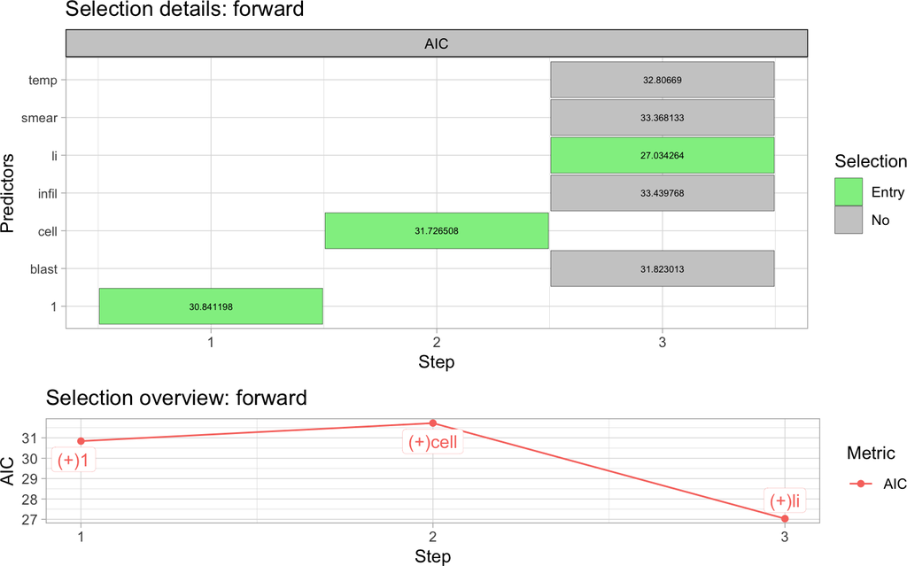

```r
plot_list <- setNames(
  lapply(c("forward"),function(i){
    setNames(
      lapply(c("detail","overview"),function(j){
        plot(res4,strategy=i,process=j)
    }),
    c("detail","overview")
    )
  }),
  c("forward")
)
cowplot::plot_grid(plotlist = plot_list$forward, ncol = 1, rel_heights = c(2, 1))
```

To get the summary of the model:

```r
summary(res4$forward$AIC)
```

```
Call:
glm(formula = remiss ~ 1 + cell + li, family = "binomial", data = data,
    weights = NULL)

Coefficients:
            Estimate Std. Error z value Pr(>|z|)
(Intercept)   -6.557      5.417  -1.211   0.2261
cell           3.030      5.458   0.555   0.5788
li             2.858      1.295   2.207   0.0273 *
---
Signif. codes:  0 '***' 0.001 '**' 0.01 '*' 0.05 '.' 0.1 ' ' 1

(Dispersion parameter for binomial family taken to be 1)

    Null deviance: 28.841  on 21  degrees of freedom
Residual deviance: 21.034  on 19  degrees of freedom
AIC: 27.034

Number of Fisher Scoring iterations: 5
```

The performance of the model:

```r
performance(res4)
```

```
                   model strategy:metric accuracy_train accuracy_test auc_train
1 remiss ~ 1 + cell + li     forward:AIC         0.7273             1    0.8571
  auc_test log_loss_train log_loss_test
1       NA         0.4781        0.1653
```

### 5.2.2 Example2: using “subset” strategy

In this example, we employ a “subset” strategy, utilizing “SBC” as the selection criteria while excluding the intercept. Meanwhile, we set `best_n = 3` to restrict the output to the top 3 models for each number of variables.

```r
formula <- remiss ~ . + 0
res5 <- stepwise(formula = formula,
                  data = remission,
                  type = "logit",
                  strategy = "subset",
                  metric = "SBC",
                  best_n = 3,
                  test_ratio = 0.2)
res5
```

```
$subset
$subset$SBC

Call:  glm(formula = remiss ~ 0 + li + temp, family = "binomial", data = data,
    weights = NULL)

Coefficients:
    li    temp
 3.018  -3.960

Degrees of Freedom: 22 Total (i.e. Null);  20 Residual
Null Deviance:      30.5
Residual Deviance: 21.31    AIC: 25.31
```

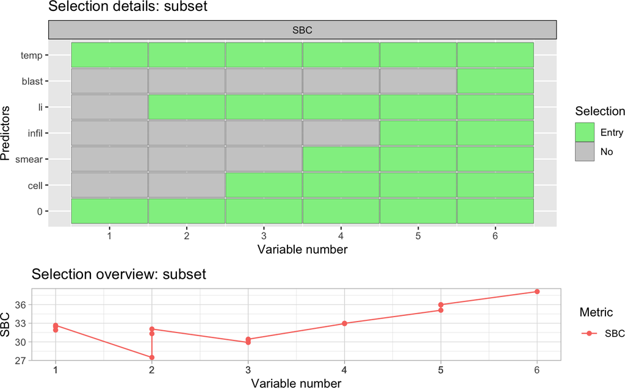

```r
plot_list <- setNames(
  lapply(c("subset"),function(i){
    setNames(
      lapply(c("detail","overview"),function(j){
        plot(res5,strategy=i,process=j)
    }),
    c("detail","overview")
    )
  }),
  c("subset")
)
cowplot::plot_grid(plotlist = plot_list$subset, ncol = 1, rel_heights = c(2, 1))
```

Here, the `0` in the above plot means that there is no intercept in the model.

To get the summary of the model:

```r
summary(res5$subset$SBC)
```

```
Call:
glm(formula = remiss ~ 0 + li + temp, family = "binomial", data = data,
    weights = NULL)

Coefficients:
     Estimate Std. Error z value Pr(>|z|)
li      3.018      1.307   2.309   0.0209 *
temp   -3.960      1.590  -2.490   0.0128 *
---
Signif. codes:  0 '***' 0.001 '**' 0.01 '*' 0.05 '.' 0.1 ' ' 1

(Dispersion parameter for binomial family taken to be 1)

    Null deviance: 30.498  on 22  degrees of freedom
Residual deviance: 21.305  on 20  degrees of freedom
AIC: 25.305

Number of Fisher Scoring iterations: 4
```

The performance of the model:

```r
performance(res5)
```

```
                   model strategy:metric accuracy_train accuracy_test auc_train
1 remiss ~ 0 + li + temp      subset:SBC         0.7727             1    0.8795
  auc_test log_loss_train log_loss_test
1       NA         0.4842         0.206
```

## 5.3 Cox regression with the `lung` dataset

In this example, we’ll demonstrate how to perform Cox regression analysis using the [`lung`] dataset. By setting `type = "cox"`, we instruct the function to conduct Cox regression.

**Description of the `lung` dataset**

The `lung` dataset, available in the `"survival"` R package, includes information on survival times for 228 patients with advanced lung cancer. It comprises ten variables, among which the “status” variable codes for censoring status (1 = censored, 2 = dead), and the “time” variable denotes the patient survival time in days.

1. inst: Institution code
2. time: Survival time in days
3. status: censoring status 1=censored, 2=dead
4. age: Age in years
5. sex: Male=1 Female=2
6. ph.ecog: ECOG performance score as rated by the physician. 0=asymptomatic, 1= symptomatic but completely ambulatory, 2= in bed < 50% of the day, 3= in bed > 50% of the day but not bedbound, 4 = bedbound
7. ph.karno: Karnofsky performance score (bad=0-good=100) rated by physician
8. pat.karno: Karnofsky performance score as rated by patient
9. meal.cal: Calories consumed at meals
10. wt.loss: Weight loss in last six months (pounds)

**Why choose Cox regression**

Cox regression, also termed the Cox proportional hazards model, is specifically designed for analyzing survival data, making it well-suited for datasets like `lung` that include information on the time until an event (e.g., death) occurs. This method accommodates censoring and assumes proportional hazards, enhancing its applicability to medical studies involving time-to-event outcomes.

### 5.3.1 Example1: using “forward” strategy with strata function in the formula

In this example, we employ a “forward” strategy with c(“AICc”, “SL”) as the selection criteria. We set the significance level for entry to 0.1 (`sle = 0.1`). We also use the `strata` function in the formula to account for the stratified analysis.

```r
data(lung)
library(survival)
lung <- na.omit(lung)
lung$sex <- factor(lung$sex, levels = c(1, 2))
str(lung)
```

```
'data.frame':   167 obs. of  10 variables:
 $ inst     : num  3 5 12 7 11 1 7 6 12 22 ...
 $ time     : num  455 210 1022 310 361 ...
 $ status   : num  2 2 1 2 2 2 2 2 2 2 ...
 $ age      : num  68 57 74 68 71 53 61 57 57 70 ...
 $ sex      : Factor w/ 2 levels "1","2": 1 1 1 2 2 1 1 1 1 1 ...
 $ ph.ecog  : num  0 1 1 2 2 1 2 1 1 1 ...
 $ ph.karno : num  90 90 50 70 60 70 70 80 80 90 ...
 $ pat.karno: num  90 60 80 60 80 80 70 80 70 100 ...
 $ meal.cal : num  1225 1150 513 384 538 ...
 $ wt.loss  : num  15 11 0 10 1 16 34 27 60 -5 ...
 - attr(*, "na.action")= 'omit' Named int [1:61] 1 3 5 12 13 14 16 20 23 25 ...
  ..- attr(*, "names")= chr [1:61] "1" "3" "5" "12" ...
```

```r
formula  =  Surv(time, status) ~ . + strata(sex)
res6 <- stepwise(formula = formula,
                 data = lung,
                 type = "cox",
                 strategy = "forward",
                 metric = c("AICc", "SL"),
                 sle = 0.1,
                 test_ratio = 0.2)
res6
```

```
$forward
$forward$AICc
Call:
coxph(formula = Surv(time, status) ~ strata(sex) + ph.ecog +
    ph.karno + inst + wt.loss, data = data, weights = NULL, method = "efron")

              coef exp(coef)  se(coef)      z        p
ph.ecog   1.098859  3.000740  0.266401  4.125 3.71e-05
ph.karno  0.029703  1.030149  0.012549  2.367   0.0179
inst     -0.030753  0.969715  0.014954 -2.056   0.0397
wt.loss  -0.015415  0.984703  0.008586 -1.795   0.0726

Likelihood ratio test=20.37  on 4 df, p=0.0004223
n= 134, number of events= 95

$forward$SL
Call:
coxph(formula = Surv(time, status) ~ strata(sex) + ph.ecog +
    ph.karno + inst + wt.loss, data = data, weights = NULL, method = "efron")

              coef exp(coef)  se(coef)      z        p
ph.ecog   1.098859  3.000740  0.266401  4.125 3.71e-05
ph.karno  0.029703  1.030149  0.012549  2.367   0.0179
inst     -0.030753  0.969715  0.014954 -2.056   0.0397
wt.loss  -0.015415  0.984703  0.008586 -1.795   0.0726

Likelihood ratio test=20.37  on 4 df, p=0.0004223
n= 134, number of events= 95
```

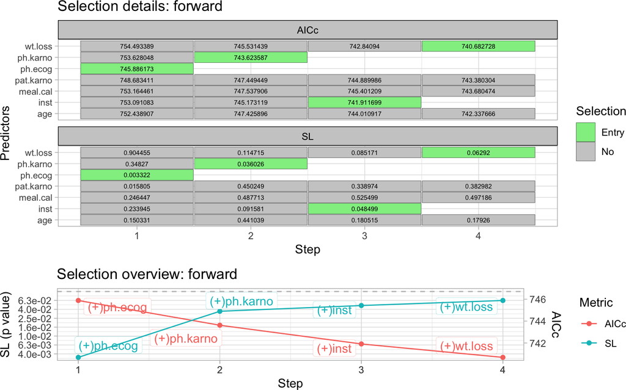

```r
plot_list <- setNames(
  lapply(c("forward"),function(i){
    setNames(
      lapply(c("detail","overview"),function(j){
        plot(res6,strategy=i,process=j)
    }),
    c("detail","overview")
    )
  }),
  c("forward")
)
cowplot::plot_grid(plotlist = plot_list$forward, ncol = 1, rel_heights = c(2, 1))
```

To get the summary of the model:

```r
summary(res6$forward$AICc)
```

```
Call:
coxph(formula = Surv(time, status) ~ strata(sex) + ph.ecog +
    ph.karno + inst + wt.loss, data = data, weights = NULL, method = "efron")

  n= 134, number of events= 95

              coef exp(coef)  se(coef)      z Pr(>|z|)
ph.ecog   1.098859  3.000740  0.266401  4.125 3.71e-05 ***
ph.karno  0.029703  1.030149  0.012549  2.367   0.0179 *
inst     -0.030753  0.969715  0.014954 -2.056   0.0397 *
wt.loss  -0.015415  0.984703  0.008586 -1.795   0.0726 .
---
Signif. codes:  0 '***' 0.001 '**' 0.01 '*' 0.05 '.' 0.1 ' ' 1

         exp(coef) exp(-coef) lower .95 upper .95
ph.ecog     3.0007     0.3333    1.7802    5.0581
ph.karno    1.0301     0.9707    1.0051    1.0558
inst        0.9697     1.0312    0.9417    0.9986
wt.loss     0.9847     1.0155    0.9683    1.0014

Concordance= 0.631  (se = 0.038 )
Likelihood ratio test= 20.37  on 4 df,   p=4e-04
Wald test            = 19.69  on 4 df,   p=6e-04
Score (logrank) test = 20.09  on 4 df,   p=5e-04
```

```r
summary(res6$forward$SL)
```

```
Call:
coxph(formula = Surv(time, status) ~ strata(sex) + ph.ecog +
    ph.karno + inst + wt.loss, data = data, weights = NULL, method = "efron")

  n= 134, number of events= 95

              coef exp(coef)  se(coef)      z Pr(>|z|)
ph.ecog   1.098859  3.000740  0.266401  4.125 3.71e-05 ***
ph.karno  0.029703  1.030149  0.012549  2.367   0.0179 *
inst     -0.030753  0.969715  0.014954 -2.056   0.0397 *
wt.loss  -0.015415  0.984703  0.008586 -1.795   0.0726 .
---
Signif. codes:  0 '***' 0.001 '**' 0.01 '*' 0.05 '.' 0.1 ' ' 1

         exp(coef) exp(-coef) lower .95 upper .95
ph.ecog     3.0007     0.3333    1.7802    5.0581
ph.karno    1.0301     0.9707    1.0051    1.0558
inst        0.9697     1.0312    0.9417    0.9986
wt.loss     0.9847     1.0155    0.9683    1.0014

Concordance= 0.631  (se = 0.038 )
Likelihood ratio test= 20.37  on 4 df,   p=4e-04
Wald test            = 19.69  on 4 df,   p=6e-04
Score (logrank) test = 20.09  on 4 df,   p=5e-04
```

The performance of the model:

```r
performance(res6)
```

```
                                                                   model
1 Surv(time, status) ~ strata(sex) + ph.ecog + ph.karno + inst + wt.loss
           strategy:metric c-index_train c-index_test auc_sh
1 forward:AICc; forward:SL        0.6309       0.4251 0.6467
```

## 5.4 Poisson regression with the `creditCard` dataset

In this example, we’ll demonstrate how to perform Poisson regression analysis using the [`creditCard`](https://search.r-project.org/CRAN/refmans/AER/html/CreditCard.html) dataset. We set `type = "poisson"` to direct the function to perform Poisson regression.

**Descprition of the `creditCard` dataset**

The `creditCard` dataset contains credit history information for a sample of applicants for a specific type of credit card, included in the `"AER"` package. It encompasses 1319 observations across 12 variables, including “reports”, “age”, “income”, among others. The “reports” variable represents the number of major derogatory reports.

1. card: Whether the credit card application was accepted (Yes/No)
2. reports: Number of major derogatory reports on the applicant’s credit history
3. age: Age in years plus twelfths of a year (e.g., 30.5 represents 30 years and 6 months)
4. income: Annual income in USD (divided by 10,000)
5. share: Ratio of monthly credit card expenditure to yearly income
6. expenditure: Average monthly credit card expenditure in USD
7. owner: Home ownership status (Yes/No)
8. selfemp: Self-employment status (Yes/No)
9. dependents: Number of dependents
10. months: Number of months living at current address
11. majorcards: Number of major credit cards held
12. active: Number of active credit accounts

**Why choose Poisson regression**

Poisson regression is frequently employed method for analyzing count data, where the response variable represents the occurrences of an event within a defined time or space frame. In the context of the `creditCard` dataset, Poisson regression can model the count of major derogatory reports (“reports”), enabling assessment of predictors’ impact on this variable.

### 5.4.1 Example1: using “forward” strategy

In this example, we employ a “forward” strategy with “SL” as the selection criteria. We set the significance level for entry to 0.05 (`sle = 0.05`).

```r
data(creditCard)
str(creditCard)
```

```
'data.frame':   1319 obs. of  12 variables:
 $ card       : Factor w/ 2 levels "no","yes": 2 2 2 2 2 2 2 2 2 2 ...
 $ reports    : num  0 0 0 0 0 0 0 0 0 0 ...
 $ age        : num  37.7 33.2 33.7 30.5 32.2 ...
 $ income     : num  4.52 2.42 4.5 2.54 9.79 ...
 $ share      : num  0.03327 0.00522 0.00416 0.06521 0.06705 ...
 $ expenditure: num  124.98 9.85 15 137.87 546.5 ...
 $ owner      : Factor w/ 2 levels "no","yes": 2 1 2 1 2 1 1 2 2 1 ...
 $ selfemp    : Factor w/ 2 levels "no","yes": 1 1 1 1 1 1 1 1 1 1 ...
 $ dependents : num  3 3 4 0 2 0 2 0 0 0 ...
 $ months     : num  54 34 58 25 64 54 7 77 97 65 ...
 $ majorcards : num  1 1 1 1 1 1 1 1 1 1 ...
 $ active     : num  12 13 5 7 5 1 5 3 6 18 ...
```

```r
formula  = reports ~ .
res7 <- stepwise(formula = formula,
                 data = creditCard,
                 type = "poisson",
                 strategy = "forward",
                 metric = "SL",
                 sle = 0.05,
                 test_ratio = 0.2)
res7
```

```
$forward
$forward$SL

Call:  glm(formula = reports ~ 1 + card + active + months + owner +
    expenditure + majorcards, family = "poisson", data = data,
    weights = NULL)

Coefficients:
(Intercept)      cardyes       active       months     owneryes  expenditure
 -0.2770025   -2.7408389    0.0625535    0.0022528   -0.3343956    0.0006102
 majorcards
  0.2812477

Degrees of Freedom: 1054 Total (i.e. Null);  1048 Residual
Null Deviance:      1906
Residual Deviance: 1029     AIC: 1562
```

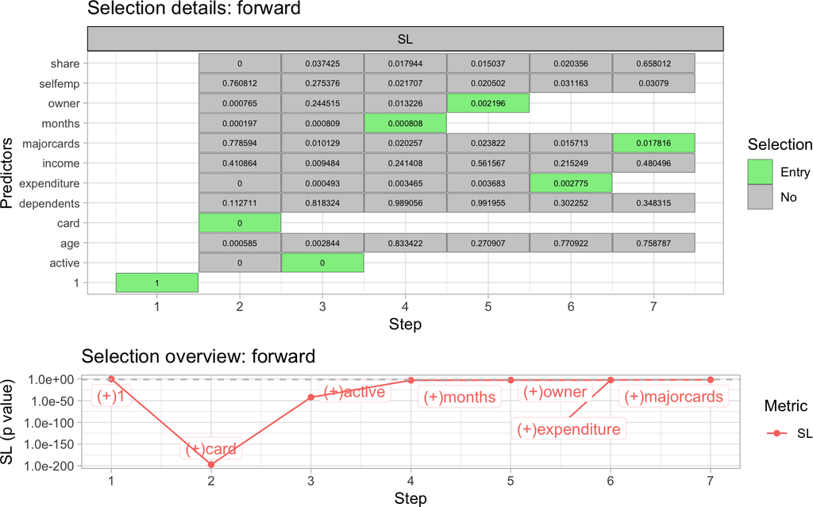

```r
plot_list <- setNames(
  lapply(c("forward"),function(i){
    setNames(
      lapply(c("detail","overview"),function(j){
        plot(res7,strategy=i,process=j)
      }),
      c("detail","overview")
    )
  }),
  c("forward")
)
cowplot::plot_grid(plotlist = plot_list$forward, ncol = 1, rel_heights = c(2, 1))
```

To get the summary of the model:

```r
summary(res7$forward$SL)
```

```
Call:
glm(formula = reports ~ 1 + card + active + months + owner +
    expenditure + majorcards, family = "poisson", data = data,
    weights = NULL)

Coefficients:
              Estimate Std. Error z value Pr(>|z|)
(Intercept) -0.2770025  0.1235492  -2.242 0.024959 *
cardyes     -2.7408389  0.1332963 -20.562  < 2e-16 ***
active       0.0625535  0.0045735  13.677  < 2e-16 ***
months       0.0022528  0.0005815   3.874 0.000107 ***
owneryes    -0.3343956  0.1036056  -3.228 0.001248 **
expenditure  0.0006102  0.0002104   2.900 0.003735 **
majorcards   0.2812477  0.1190842   2.362 0.018189 *
---
Signif. codes:  0 '***' 0.001 '**' 0.01 '*' 0.05 '.' 0.1 ' ' 1

(Dispersion parameter for poisson family taken to be 1)

    Null deviance: 1906.1  on 1054  degrees of freedom
Residual deviance: 1029.3  on 1048  degrees of freedom
AIC: 1562

Number of Fisher Scoring iterations: 6
```

The performance of the model:

```r
performance(res7)
```

```
                                                                            model
1 reports:reports ~ 1 + card + active + months + owner + expenditure + majorcards
  strategy:metric mse_train mse_test mae_train mae_test response
1      forward:SL    6.8877   5.8562    1.4953    2.117  reports
```

# 6 Interactive app

We have developed an interactive Shiny application to simplify model selection tasks for non-programmers. You can access the app through the following URL:

https://junhuili1017.shinyapps.io/StepRegShiny/

You can also access the Shiny app directly from your local machine with the following code:

```r
library(StepRegShiny)
StepRegGUI()
```

Here is the user interface.

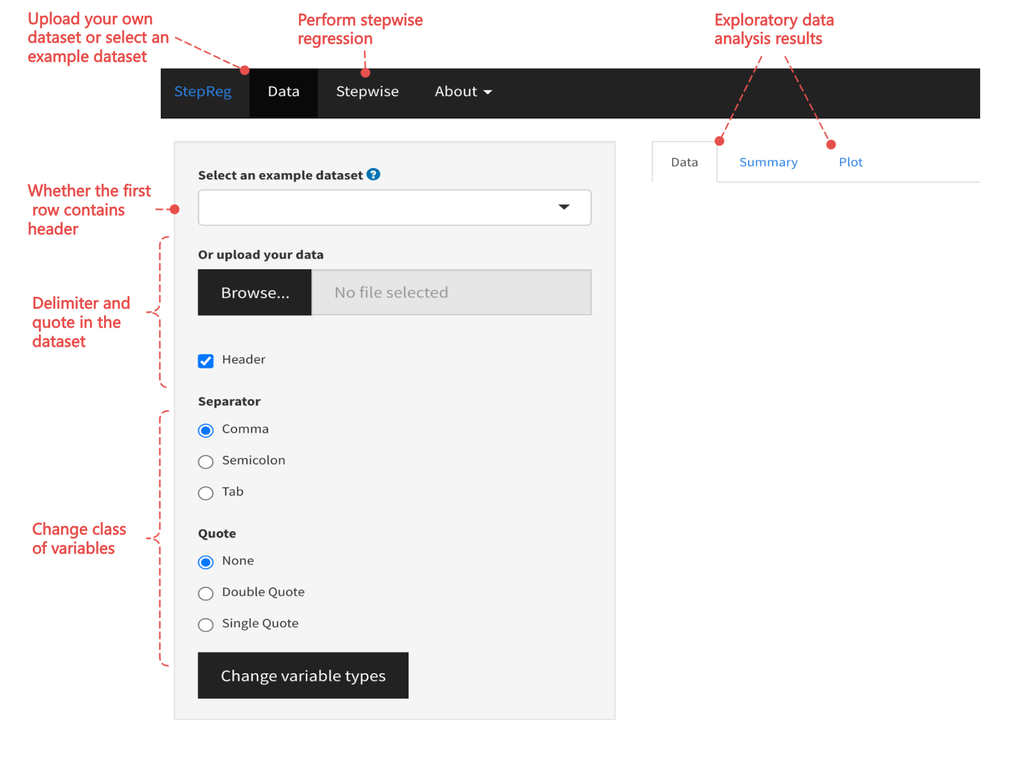

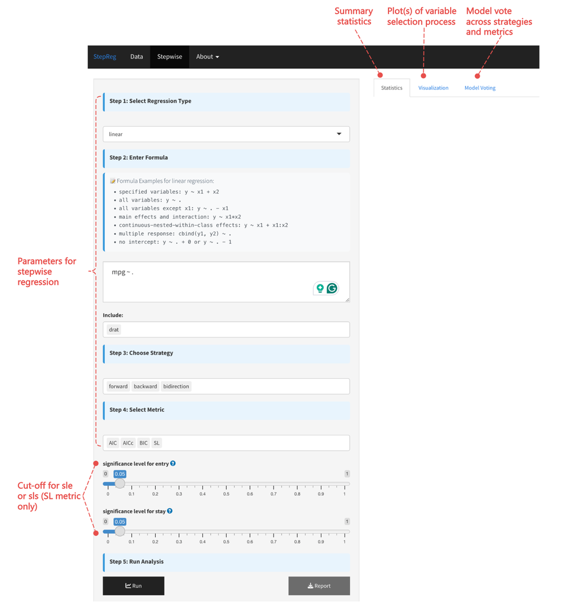

A. F. M. Smith, D. J. Spiegelhalter. 1980. “Bayes Factors and Choice Criteria for Linear Model.” Journal Article. *Journal of the Royal Statistical Society. Series B (Methodological)* 42 (2): 213–20.

Allan D R McQuarrie, Chih-Ling Tsai. 1998. *Regression and Time Series Model Selection*. Book. River Edge, NJ.: World Scientific Publishing Co. Pte. Ltd.

Al-Subaihi, Ali A. 2002. “Variable Selection in Multivariable Regression Using SAS/IML.” Journal Article. *Journal of Statistical Software* 7 (12): 1–20.

Clifford M. Hurvich, Chih-Ling Tsai. 1989. “Regression and Time Series Model Selection in Small Samples.” Journal Article. *Biometrika* 76: 297–307.

Darlington, R. B. 1968. “Multiple Regression in Psychological Research and Practice.” Journal Article. *Psychological Bulletin* 69 (3): 161–82.

E. J. Hannan, B. G. Quinn. 1979. “The Determination of the Order of an Autoregression.” Journal Article. *Journal of the Royal Statistical Society. Series B (Methodological)* 41 (2): 190–95.

Edward J. Bedrick, Chih-Ling Tsai. 1994. “Model Selection for Multivariate Regression in Small Samples.” Journal Article. *Biometrics* 50 (1): 226–31.

George G. Judge, R. Carter Hill, William E. Griffiths. 1985. *The Theory and Practice of Econometrics, 2nd Edition*. Book. Wiley. https://www.wiley.com/en-us/The+Theory+and+Practice+of+Econometrics%2C+2nd+Edition-p-9780471895305.

Hocking, R. R. 1976. “A Biometrics Invited Paper. The Analysis and Selection of Variables in Linear Regression.” Journal Article. *Biometrics* 32 (1): 1–49.

Hotelling, Harold. 1992. “The Generalization of Student’s Ratio.” Book Section. In *Breakthroughs in Statistics: Foundations and Basic Theory.*, 54–62.

J. A. Nelder, R. W. M. Wedderburn. 1972. “Generalized Linear Models.” Journal Article. *Journal of the Royal Statistical Society. Series A (General)* 135 (3): 370–84.

K. V. Mardia, J. M. Bibby, J. T. Ken. 1981. “Multivariate Analysis.” Journal Article. *Mathematical Gazette* 65 (431): 75–76.

Kenneth P. Burnham, David R. Anderson. 2002. *Model Selection and Multimodel Inference: A Practical Information-Theoretic Approach 2nd Edition*. Book. Springer.

Mallows, C. L. 1973. “Some Comments on CP.” Journal Article. *Technometrics* 15 (4): 661–75.

Mark J. Brewer, Susan L. Cooksley, Adam Butler. 2016. “The Relative Performance of AIC, AICC and BIC in the Presence of Unobserved Heterogeneity.” Journal Article. *Methods in Ecology and Evolution* 7 (6): 679–92.

McKEON, JAMES J. 1974. “F Approximations to the Distribution of Hotelling’s T20.” Journal Article. *Biometrika* 61 (2): 381–83.

Pillai, K. C. S. 1995. “Some New Test Criteria in Multivariate Analysis.” Journal Article. *Ann. Math. Statist* 26 (1): 117–21.

Prathapasinghe Dharmawansa, Ofer Shwartz, Boaz Nadler. 2014. “Roy’s Largest Root Under Rank-One Alternatives:the Complex Valued Case and Applications.” Journal Article. *arXiv Preprint arXiv* 1411: 4226.

RS Sparks, D Coutsourides, W Zucchini. 1985. “On Variable Selection in Multivariate Regression.” Journal Article. *Communication in Statistics- Theory and Methods* 14 (7): 1569–87.

SAS Institute Inc. 2018. *SAS/STAT® 15.1 User’s Guide*. Book. Cary, NC: SAS Institute Inc.

Sawa, Takamitsu. 1978. “Information Criteria for Discriminating Among Alternative Regression Models.” Journal Article. *Econometrica* 46 (6): 1273–91.

Schwarz, Gideon. 1978. “Estimating the Dimension of a Model.” Journal Article. *Ann. Statist.* 6 (2): 461–64.

Stevens, James P. 2016. *Applied Multivariate Statistics for the Social Sciences*. Book. Fifth Edition. Routledge.